# 1 Spatial foundation models for the Bioconductor community

Source code: https://github.com/drighelli/BiocFoundationGPU

## 1.1 Motivation

Foundation models for spatial data are predominantly distributed as Python packages, and configuring them for a particular compute environment is often fragile: most have specific version dependencies that are not always documented, even when the model is on PyPI. This makes individual models hard to install for many R users and makes reproducible benchmarking across models onerous. The `BiocFoundationGPU` package addresses both problems.

## 1.2 Package overview

`BiocFoundationGPU` configures and runs foundation-model pipelines from R. It uses `basilisk` and `reticulate` to build separate environments per model (Figure 1), avoiding the dependency conflicts that arise when attempting to satisfy all models in a single environment. The package ships a collection of `BasiliskEnvironment` schemas that pin a Python version and the required PyPI dependencies for each model. For models not on PyPI, `BiocFoundationGPU` provides template scripts to build environments via `reticulate`.

[figure not shown]

For each supported model, the package exports a `Run_<model>()` function (e.g., `Run_novae()`). The package focuses on **zero-shot** use of pre-trained models: input data are passed in and embeddings come back, with no fine-tuning required. The final design takes a `SpatialExperiment` as input and writes embeddings to its `reducedDims` slot.

## 1.3 Models

Six models spanning the breadth of current spatial-foundation use cases were prioritized (Table 1). Wherever possible, weights are pulled from Hugging Face so the entire workflow runs through the package; the exception is scGPT, which uses upstream PyTorch checkpoints.

Table 1: Models packaged in `BiocFoundationGPU`. ✅ = exposed via `Run_*()`, 🟡 = environment recipe shipped but no wrapper yet, ❌ = not currently runnable through the package.

| Status | Model | Category | PyPI | Primary input | Output | Embedding size |
| --- | --- | --- | --- | --- | --- | --- |
| ✅ | scGPT<sup>1</sup> | Single-cell transcriptomics | ✅ | Gene counts | Cell embeddings | 512 |
| 🟡 | scFoundation<sup>2</sup> | Single-cell transcriptomics | ✅ | Gene counts | Gene / cell embeddings | 3072 |
| ✅ | Novae<sup>3</sup> | Spatial transcriptomics | ✅ | Gene counts + spatial coords | Neighbor-context embedding + zero-shot domains | 64 |
| 🟡 | Prov-GigaPath<sup>4</sup> | H&E imaging | ❌ | H&E WSI tiles | Tile / slide embeddings | tile 1536, slide 768 |
| ✅ | Nimbus<sup>5</sup> | Spatial proteomics | ✅ | Multiplex TIFF + segmentation mask | Per-cell expression estimates and annotations | — |
| ❌ | KRONOS<sup>6</sup> | Spatial proteomics | ❌ | TIFF + mask + marker annotation | Per-patch embeddings | 384 |

### 1.3.1 Model implementations

**scGPT.** While not designed for spatial data, transcriptional profiles from spatial assays can be passed through it for comparison with spatial-specific models. (A spatial extension is available<sup>7</sup> but not yet integrated.) Our implementation uses upstream PyTorch checkpoints (`.pt` plus support `.json` files) rather than the Hugging Face port, because scGPT distributes multiple pretrained checkpoints and working with them directly preserves user choice. `Run_scGPT()` takes the path to an `.h5ad` file and the directory containing the pretrained model.

**Novae.** Embeddings are accessible from the returned `AnnData` at `adata$obsm$novae_latent`, domain assignments at `adata$obs$novae_domains_7`. Novae runs on CUDA GPUs and Apple Metal Performance Shaders (MPS).

**Prov-GigaPath.** Integration is in progress. The current blocker is provisioning the Python environment on remote GPU servers: the required Python build is slow to download and a robust install pattern for that setting is still being worked out.

**Nimbus.** Operates marker by marker across the multiplexed image, which makes it portable across multiplexed-imaging platforms with different channel counts.

KRONOS<sup>6</sup> is a foundation model purpose-built for spatial proteomics. It was trained on more than 47 million image patches covering 16 tissue types and 175 protein markers, and uses a Vision Transformer based on DINOv2 modified to handle highly multiplexed images. KRONOS extracts 384-dimensional embeddings for each patch, which can be used for cell phenotyping, artifact detection, or outcome prediction.

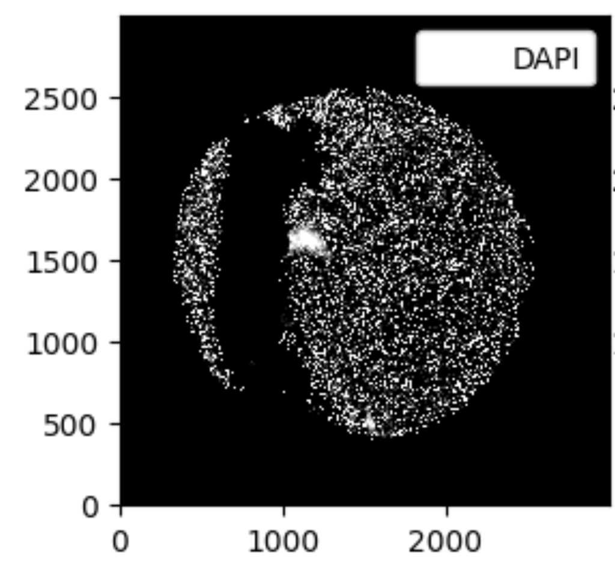

Figure 2: Original DAPI channel of the multiplexed input image.

## 1.4 End-to-end compatibility with `SpatialExperiment`

The package design takes a `SpatialExperiment` in and returns embeddings to the same object. Because most Python tools expect `AnnData`, we extended `anndataR` to support bidirectional conversion between the two formats — layering a spatially aware translation on top of the existing `SingleCellExperiment` conversion framework. Canonical mappings for assays, feature- and cell-level annotations, dimensionality reductions, and graph-like pairwise structures are preserved; the new logic adds explicit handling for spatial state. Forward (R → Python), `spatialCoords` are serialized to `obsm["spatial"]` and image metadata from `imgData` is written to `uns["spatial"]` in a library-indexed nested layout compatible with Scanpy conventions; in reverse (Python → R), those structures are parsed to reconstruct `SpatialExperiment` objects with restored coordinates and images.

The central difficulty is that `SpatialExperiment` carries semantics that are not native to `AnnData`: spatial coordinates are not generic embeddings, image metadata are heterogeneous and partially technology-specific, and multi-library datasets require deterministic reconciliation between observation-level sample annotations and image-level library identifiers. To address these we introduced reserved spatial keys, conflict checks against user-defined `obsm` and `uns` mappings, and a round-trip metadata container under `uns["anndataR_spatialexperiment"]` that preserves otherwise non-canonical information (original coordinate names, selected spatial keys, library identifier provenance, image export mode). Image payloads can be embedded, referenced, or omitted to balance interoperability, file size, and reversibility.

The current development branch can be installed with:

```r
remotes::install_github("drighelli/anndataR@from_as_spe")
```

### 1.4.1 Testing the conversion

Preliminary evaluation surfaces discrepancies in specific configurations, particularly those involving technology-specific spatial metadata or image representations. The reproducibility case study in the `renovae` repository (https://github.com/sales-lab/renovae) documents one such mismatch and will help us locate the remaining failure points before the work is upstreamed as a pull request to `anndataR`.

## References

1.

Cui, H. *et al.* [scGPT: Toward building a foundation model for single-cell multi-omics using generative AI](https://doi.org/10.1038/s41592-024-02201-0). *Nature Methods* **21**, 1470–1480 (2024).

2.

Hao, M. *et al.* [Large-scale foundation model on single-cell transcriptomics](https://doi.org/10.1038/s41592-024-02305-7). *Nature Methods* **21**, 1481–1491 (2024).

3.

Quentin, B., Hakim, B., Nadège, B., Fabrice, A. & Paul-Henry, C. Novae: A graph-based foundation model for spatial transcriptomics data. *bioRxiv* https://doi.org/10.1101/2024.09.09.612009 (2024) doi:10.1101/2024.09.09.612009.

4.

Xu, H. *et al.* [A whole-slide foundation model for digital pathology from real-world data](https://doi.org/10.1038/s41586-024-07441-w). *Nature* **630**, 181–188 (2024).

5.

Rumberger, J. L. *et al.* Automated classification of cellular expression in multiplexed imaging data with nimbus. *Nature Methods* **22**, 2161–2170 (2025).

6.

Shaban, M. *et al.* A foundation model for spatial proteomics. *arXiv preprint arXiv:2506.03373* (2025).

7.

Wang, C. *et al.* scGPT-spatial: Continual pretraining of single-cell foundation model for spatial transcriptomics. *biorxiv* 2025–02 (2025).